# Peer Assessment II

# 1 Background

As a statistical consultant working for a real estate investment firm, your task is to develop a model to predict the selling price of a given home in Ames, Iowa. Your employer hopes to use this information to help assess whether the asking price of a house is higher or lower than the true value of the house. If the home is undervalued, it may be a good investment for the firm.

# 2 Training Data and relevant packages

In order to better assess the quality of the model you will produce, the data have been randomly divided into three separate pieces: a training data set, a testing data set, and a validation data set. For now we will load the training data set, the others will be loaded and used later.

```r
load("ames_train.Rdata")
```

Use the code block below to load any necessary packages

```r
library(statsr)
library(dplyr)
library(BAS)
library(MASS)
library(corrplot)
library(ggplot2)
library(knitr)
library(GGally)
```

## 2.1 Part 1 - Exploratory Data Analysis (EDA)

When you first get your data, it’s very tempting to immediately begin fitting models and assessing how they perform. However, before you begin modeling, it’s absolutely essential to explore the structure of the data and the relationships between the variables in the data set.

Do a detailed EDA of the ames_train data set, to learn about the structure of the data and the relationships between the variables in the data set (refer to Introduction to Probability and Data, Week 2, for a reminder about EDA if needed). Your EDA should involve creating and reviewing many plots/graphs and considering the patterns and relationships you see.

After you have explored completely, submit the three graphs/plots that you found most informative during your EDA process, and briefly explain what you learned from each (why you found each informative).

```r
dim(ames_train)
```

```
## [1] 1000   81
```

The dataset has 1000 observations and 81 variables. We will look at the first 6 rows of data to view the data before doing analysis

```r
head(ames_train)
```

```
## # A tibble: 6 x 81
##      PID  area  price MS.SubClass MS.Zoning Lot.Frontage Lot.Area Street
##    <int> <int>  <int>       <int> <fct>            <int>    <int> <fct>
## 1 9.09e8   856 126000          30 RL                  NA     7890 Pave
## 2 9.05e8  1049 139500         120 RL                  42     4235 Pave
## 3 9.11e8  1001 124900          30 C (all)             60     6060 Pave
## 4 5.35e8  1039 114000          70 RL                  80     8146 Pave
## 5 5.34e8  1665 227000          60 RL                  70     8400 Pave
## 6 9.08e8  1922 198500          85 RL                  64     7301 Pave
## # ... with 73 more variables: Alley <fct>, Lot.Shape <fct>,
## #   Land.Contour <fct>, Utilities <fct>, Lot.Config <fct>,
## #   Land.Slope <fct>, Neighborhood <fct>, Condition.1 <fct>,
## #   Condition.2 <fct>, Bldg.Type <fct>, House.Style <fct>,
## #   Overall.Qual <int>, Overall.Cond <int>, Year.Built <int>,
## #   Year.Remod.Add <int>, Roof.Style <fct>, Roof.Matl <fct>,
## #   Exterior.1st <fct>, Exterior.2nd <fct>, Mas.Vnr.Type <fct>,
## #   Mas.Vnr.Area <int>, Exter.Qual <fct>, Exter.Cond <fct>,
## #   Foundation <fct>, Bsmt.Qual <fct>, Bsmt.Cond <fct>,
## #   Bsmt.Exposure <fct>, BsmtFin.Type.1 <fct>, BsmtFin.SF.1 <int>,
## #   BsmtFin.Type.2 <fct>, BsmtFin.SF.2 <int>, Bsmt.Unf.SF <int>,
## #   Total.Bsmt.SF <int>, Heating <fct>, Heating.QC <fct>,
## #   Central.Air <fct>, Electrical <fct>, X1st.Flr.SF <int>,
## #   X2nd.Flr.SF <int>, Low.Qual.Fin.SF <int>, Bsmt.Full.Bath <int>,
## #   Bsmt.Half.Bath <int>, Full.Bath <int>, Half.Bath <int>,
## #   Bedroom.AbvGr <int>, Kitchen.AbvGr <int>, Kitchen.Qual <fct>,
## #   TotRms.AbvGrd <int>, Functional <fct>, Fireplaces <int>,
## #   Fireplace.Qu <fct>, Garage.Type <fct>, Garage.Yr.Blt <int>,
## #   Garage.Finish <fct>, Garage.Cars <int>, Garage.Area <int>,
## #   Garage.Qual <fct>, Garage.Cond <fct>, Paved.Drive <fct>,
## #   Wood.Deck.SF <int>, Open.Porch.SF <int>, Enclosed.Porch <int>,
## #   X3Ssn.Porch <int>, Screen.Porch <int>, Pool.Area <int>, Pool.QC <fct>,
## #   Fence <fct>, Misc.Feature <fct>, Misc.Val <int>, Mo.Sold <int>,
## #   Yr.Sold <int>, Sale.Type <fct>, Sale.Condition <fct>
```

Next, we will look at the structure of the data

```r
str(ames_train)
```

```
## Classes 'tbl_df', 'tbl' and 'data.frame':    1000 obs. of  81 variables:
##  $ PID            : int  909176150 905476230 911128020 535377150 534177230 908128060 902135020 528228540 923426010 908186050 ...
##  $ area           : int  856 1049 1001 1039 1665 1922 936 1246 889 1072 ...
##  $ price          : int  126000 139500 124900 114000 227000 198500 93000 187687 137500 140000 ...
##  $ MS.SubClass    : int  30 120 30 70 60 85 20 20 20 180 ...
##  $ MS.Zoning      : Factor w/ 7 levels "A (agr)","C (all)",..: 6 6 2 6 6 6 7 6 6 7 ...
##  $ Lot.Frontage   : int  NA 42 60 80 70 64 60 53 74 35 ...
##  $ Lot.Area       : int  7890 4235 6060 8146 8400 7301 6000 3710 12395 3675 ...
##  $ Street         : Factor w/ 2 levels "Grvl","Pave": 2 2 2 2 2 2 2 2 2 2 ...
##  $ Alley          : Factor w/ 2 levels "Grvl","Pave": NA NA NA NA NA NA 2 NA NA NA ...
##  $ Lot.Shape      : Factor w/ 4 levels "IR1","IR2","IR3",..: 4 4 4 4 4 4 4 4 4 4 ...
##  $ Land.Contour   : Factor w/ 4 levels "Bnk","HLS","Low",..: 4 4 4 4 4 4 1 4 4 4 ...
##  $ Utilities      : Factor w/ 3 levels "AllPub","NoSeWa",..: 1 1 1 1 1 1 1 1 1 1 ...
##  $ Lot.Config     : Factor w/ 5 levels "Corner","CulDSac",..: 1 5 5 1 5 1 5 5 1 5 ...
##  $ Land.Slope     : Factor w/ 3 levels "Gtl","Mod","Sev": 1 1 1 1 1 1 2 1 1 1 ...
```

[output cut: 67 more lines]

There are two categorical variables are coded in R as having type int. We need to change them to factors when conducting analysis.

```r
ames_train$Overall.Qual <- factor(ames_train$Overall.Qual,ordered = TRUE)
ames_train$Overall.Cond <- factor(ames_train$Overall.Cond,ordered = TRUE)
```

From `str` of the data, we saw that there are some variables having missing data and three variables with the highest number of missing observations are `Misc.Feature`, `Alley` and `Pool.QC`

```r
na_count <- colSums(is.na(ames_train))
head(sort(na_count, decreasing = TRUE), 3)
```

```
##      Pool.QC Misc.Feature        Alley
##          997          971          933
```

In our case, removing all NA from the dataset will affect our analysis. For example, `Pool.QC` has the higest number of NA’s. This number is likely high as “NA” is coded as “No Pool” in the data and not all of houses must have a pool. Another example is that NA values for Basement.Qual and Garage.Qual correspond to houses that do not have a basement or a garage respectively. Thus, the best way to deal with these NA values when fitting the linear model with these variables is recoding all NA values as a separate category.

### 2.1.1 Distribution of price

The purpose of this project is building a model to predict the price for all houses in Ames. So we will perform summary statistics and look at the distribution of the `price` first

```r
ames_train %>%
    summarize(Q1 = quantile(price, 0.25), MEAN = mean(price),
              MEDIAN = median(price),Q3 = quantile(price, 0.75),               IQR = IQR(price), STDEV = sd(price)) %>%
              mutate(SKEW = ifelse(MEAN > MEDIAN,
                                   "RIGHT", "LEFT"))
```

```
## # A tibble: 1 x 7
##        Q1    MEAN MEDIAN     Q3    IQR  STDEV SKEW
##     <dbl>   <dbl>  <dbl>  <dbl>  <dbl>  <dbl> <chr>
## 1 129762. 181190. 159467 213000 83238. 81910. RIGHT
```

Average price for all houses in Ames is $181,190 which is higher than the median of the house

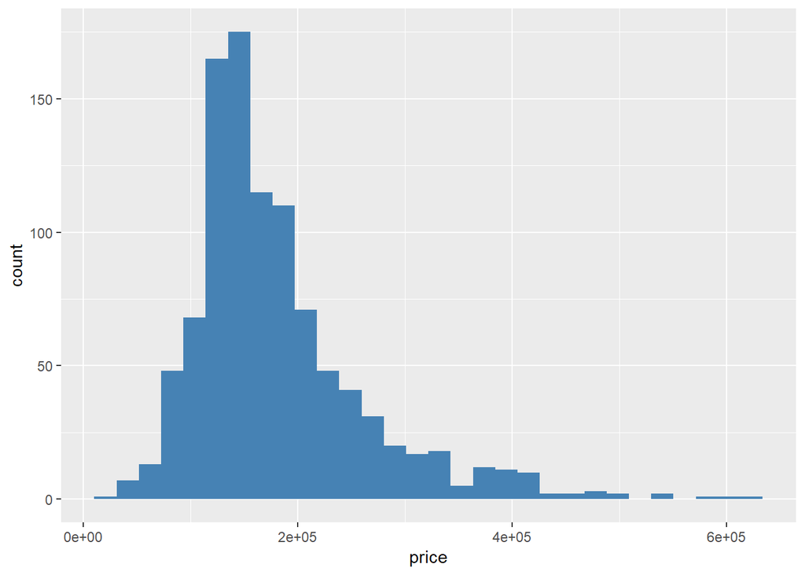

```r
ggplot(ames_train, aes(x= price)) +
  geom_histogram(bins = 30, fill = 'steelblue')
```

The distribution of `price` is right-skewed so median will be recommended to be used over the mean for analysis. Also, as `price` is right-skewed and it will be used as a dependent variable in a linear regression later, so we should log-transform `price`

#### 2.1.1.1 The ages of the houses

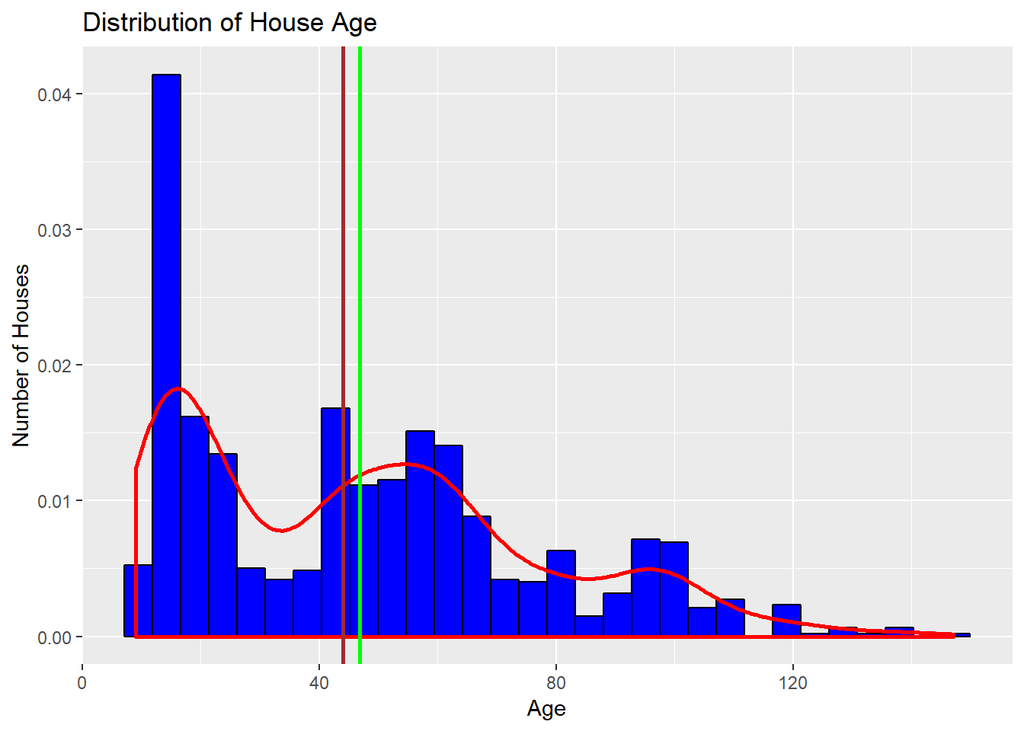

```r
ames_train$age <- sapply(ames_train$Year.Built, function(x) 2019 - x)

ggplot(ames_train, aes(x = age, y =..density..)) +
  geom_histogram(bins = 30, fill = 'blue', colour = 'black') +
  geom_density(size = 1, colour = 'red') +
  labs(title = 'Distribution of House Age', x = 'Age', y = 'Number of Houses') +
  geom_vline(xintercept = mean(ames_train$age), colour = 'green', size = 1) +
  geom_vline(xintercept = median(ames_train$age), colour = 'brown', size = 1)
```

```r
summary_age <- ames_train %>%
  summarize(Mean_age = mean(age),
            Median_age = median(age),
            Sd_age = sd(age),
            Q1 = quantile(age, 0.25),
            Q3 = quantile(age, 0.75),
            IQR = IQR(age),
            Total = n())
summary_age
```

```
## # A tibble: 1 x 7
##   Mean_age Median_age Sd_age    Q1    Q3   IQR Total
##      <dbl>      <dbl>  <dbl> <dbl> <dbl> <dbl> <int>
## 1     46.8         44   29.6    18    64    46  1000
```

The distribution of `age’ is righ-skewed (the mean is 46.797, median is 44) and showed multimodal behaviour indicating that there are some high counts of houses for certain ages (such as 50 and 90). There is an decrease in number of houses as the age of houses increase.

### 2.1.2 Home price to its neighborhood

The mantra in real estate is “Location, Location, Location!” We will do summary statistics about home price to its neighborhood for determining the most expensive, least expensive, and most heterogeneous (having the most variation in housing price) neighborhoods

```r
# Perform summary statistics

q2 <- ames_train %>%
  group_by(Neighborhood) %>%
  summarise(mean_price = mean(price),
            median_price = median(price),
            min_price = min(price),
            max_price = max(price),
            IQR = IQR(price),
            sd_price = sd(price),
            var_price = var(price),
            total = n())

# Determine most expensive, lease expensive and most heterogeneous

most_expensive <- q2[which(q2$median_price == max(q2$median_price)),]
least_expensive <- q2[which(q2$median_price == min(q2$median_price)),]
most_heter <- q2[which(q2$sd_price == max(q2$sd_price)),]

kable(most_expensive[1:9], caption = 'Most expensive houses')
```

Most expensive houses

| Neighborhood | mean_price | median_price | min_price | max_price | IQR | sd_price | var_price | total |
| --- | --- | --- | --- | --- | --- | --- | --- | --- |
| StoneBr | 339316 | 340691.5 | 180000 | 591587 | 151358 | 123459.1 | 15242150036 | 20 |

```r
kable(least_expensive[1:9], caption = 'Least expensive houses')
```

Least expensive houses

| Neighborhood | mean_price | median_price | min_price | max_price | IQR | sd_price | var_price | total |
| --- | --- | --- | --- | --- | --- | --- | --- | --- |
| MeadowV | 92946.88 | 85750 | 73000 | 129500 | 20150 | 18939.78 | 358715156 | 16 |

```r
kable(most_heter[1:9], caption = 'Most heterogeneous houses')
```

Most heterogeneous houses

| Neighborhood | mean_price | median_price | min_price | max_price | IQR | sd_price | var_price | total |
| --- | --- | --- | --- | --- | --- | --- | --- | --- |
| StoneBr | 339316 | 340691.5 | 180000 | 591587 | 151358 | 123459.1 | 15242150036 | 20 |

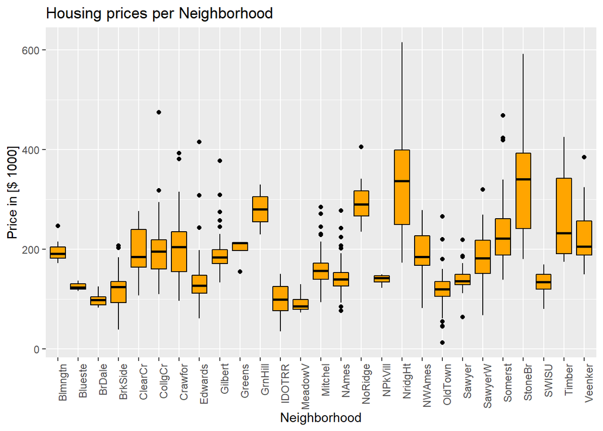

```r
# Plot
ggplot(ames_train, aes(x = Neighborhood, y = price/1000)) +
  geom_boxplot(colour = 'black', fill = 'orange') +
  labs(title = "Housing prices per Neighborhood", x = 'Neighborhood', y = "Price in [$ 1000]") +
  theme(axis.text.x = element_text(angle = 90, hjust = 1))
```

According to the chart, StoneBr is the most expensive and most heterogeneous neighborhood, follow by NridgHt while the least expensive Neighborhood is MeadowV. We can create different plots for StoneBr and NridgHt

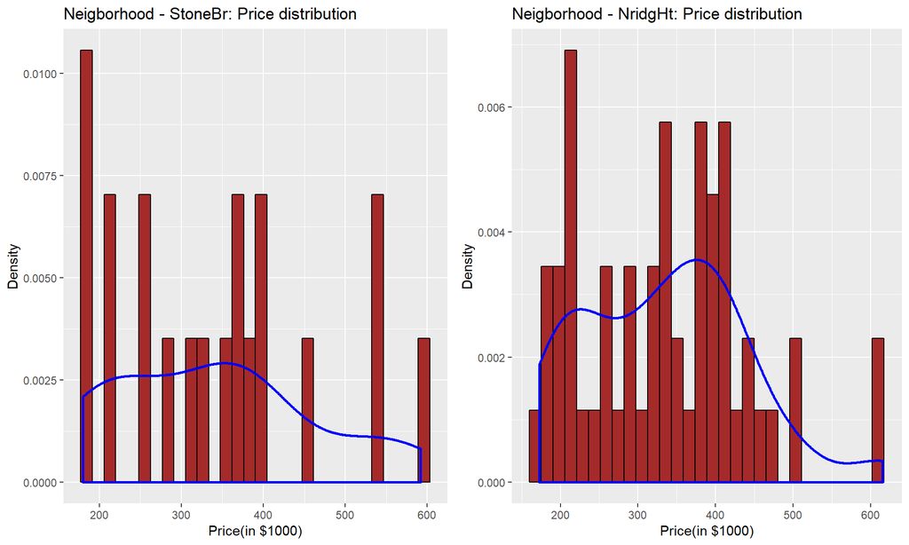

```r
stone <- ames_train %>%
  filter(Neighborhood == 'StoneBr')

p1 <- ggplot(stone, aes(x = price/1000, y = ..density..)) +
  geom_histogram(bins = 30, colour = 'black', fill = 'brown') +
  geom_density(size = 1, colour = 'blue') +
  labs(title = 'Neigborhood - StoneBr: Price distribution', x = 'Price(in $1000)', y = 'Density')

nrid <- ames_train %>%
  filter(Neighborhood == 'NridgHt')

p2 <- ggplot(nrid, aes(x = price/1000, y = ..density..)) +
  geom_histogram(bins = 30, colour = 'black', fill = 'brown') +
  geom_density(size = 1, colour = 'blue') +
  labs(title = 'Neigborhood - NridgHt: Price distribution', x = 'Price(in $1000)', y = 'Density')
library(gridExtra)
grid.arrange(p1, p2, ncol = 2)
```

### 2.1.3 Overal.Qual in association with price

To know if Lot.Area, Bedroom.AbvGr, Overall.Qual and Year.Built affect the price of houses in Ames or not, we will look at the following charts:

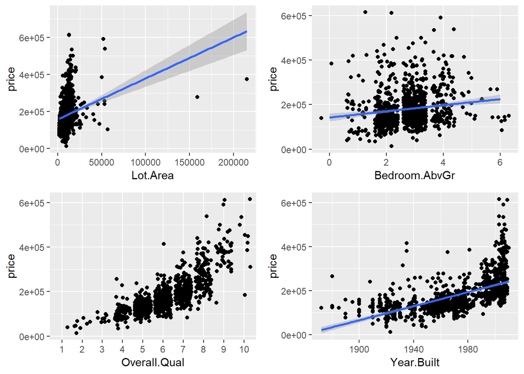

```r
# Lot.Area
p1 <- ggplot(ames_train, aes(x = Lot.Area, y = price)) +
  geom_point() +
  stat_smooth(method = 'lm')

# Bedroom.AbvGr
p2 <- ggplot(ames_train, aes(x = Bedroom.AbvGr, y = price)) +
  geom_jitter() +
  stat_smooth(method = 'lm')

# Overall.Qual
p3 <- ggplot(ames_train, aes(x = Overall.Qual, y = price)) +
  geom_jitter()+
  stat_smooth(method = 'lm')

# Year.Built
p4 <- ggplot(ames_train, aes(x = Year.Built, y = price)) +
  geom_point()+
  stat_smooth(method = 'lm')

grid.arrange(p1, p2, p3, p4, ncol = 2)
```

From the chart, Overall.Qual appears to be the best single predictor of price.

### 2.1.4 Variable correlation matrix

We will perform correlation matrix to identify top of the most infuencial variables to the price. The correlation coefficient measures the linearly between 2 variables.

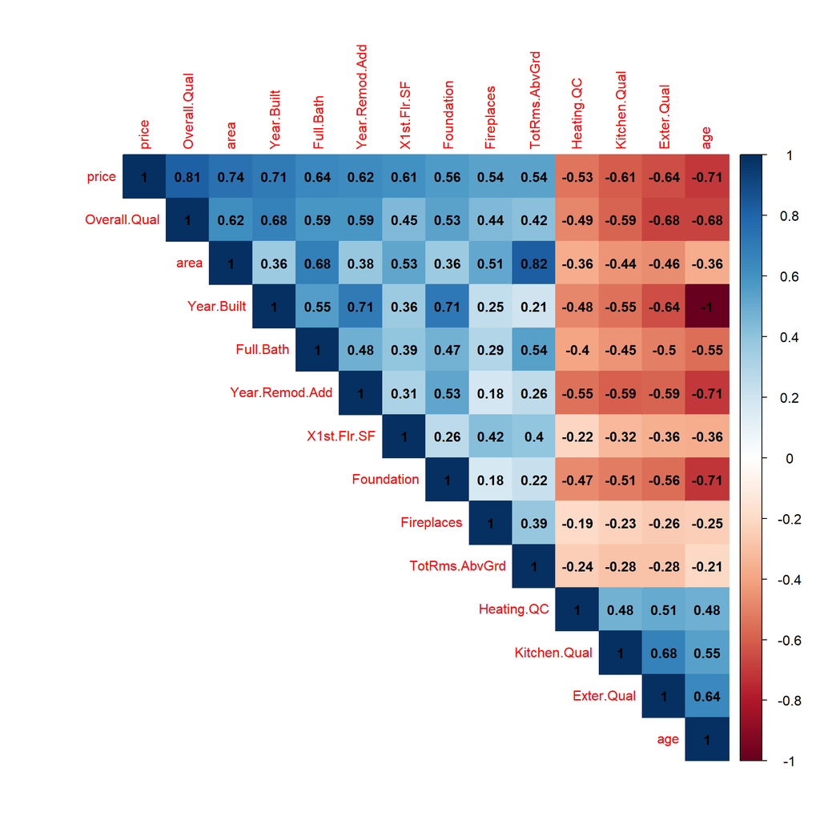

```r
# Convert entire dataframe to numeric
data.corr <- as.data.frame(sapply(ames_train, as.numeric))
correlations = cor(data.corr, method = "s")
# Show variables that have strong correlations with price, focus on coefficient > 0.5 or < -0.5
corr.price = as.matrix(sort(correlations[,'price'], decreasing = TRUE))
corr.id = names(which(apply(corr.price, 1, function(x) (x > 0.5 | x < -0.5))))
corrplot(as.matrix(correlations[corr.id,corr.id]), type = 'upper', method='color', addCoef.col = 'black', tl.cex = 1,cl.cex = 1, number.cex=1)
```

## 2.2 Part 2 - Development and assessment of an initial model, following a semi-guided process of analysis

### 2.2.1 Section 2.1 An Initial Model

In building a model, it is often useful to start by creating a simple, intuitive initial model based on the results of the exploratory data analysis. (Note: The goal at this stage is **not** to identify the “best” possible model but rather to choose a reasonable and understandable starting point. Later you will expand and revise this model to create your final model.

Based on your EDA, select *at most* 10 predictor variables from âames_trainâ and create a linear model for `price` (or a transformed version of price) using those variables. Provide the *R code* and the *summary output table* for your model, a *brief justification* for the variables you have chosen, and a *brief discussion* of the model results in context (focused on the variables that appear to be important predictors and how they relate to sales price).

There are a lot of factors that affect the price of a house. In this section, We will pick 10 variables to be predictors for price and log-transform `price` and `area` (mentioned in EAD)

- Overall.Qual: people will look at this information first when choosing a house or deciding to buy a house
- Bedroom.AbvGr: number of bedroom may be one of concern when people go shopping for a house
- Area: most often, a house with large area will cost more
- Lot.Area: the position of a house will affect the price
- Year.Built: in general, new house will be more expensive than old house
- Garage.Area, Total.Bsmt.SF, Garage.Cars, Full.Bath and X1st.Flr.SF will affct the price too

```r
# Full Model
model.full <- lm(log(price) ~ Overall.Qual + Garage.Area +
                   Total.Bsmt.SF + Garage.Cars + log(area) +
                   Full.Bath + Bedroom.AbvGr + Year.Built +
                   X1st.Flr.SF + Lot.Area, data = ames_train)
summary(model.full)
```

```
##
## Call:
## lm(formula = log(price) ~ Overall.Qual + Garage.Area + Total.Bsmt.SF +
##     Garage.Cars + log(area) + Full.Bath + Bedroom.AbvGr + Year.Built +
##     X1st.Flr.SF + Lot.Area, data = ames_train)
##
## Residuals:
##      Min       1Q   Median       3Q      Max
## -1.42804 -0.07357  0.00684  0.08424  0.65793
##
## Coefficients:
##                  Estimate Std. Error t value Pr(>|t|)
## (Intercept)     2.447e+00  5.828e-01   4.198 2.93e-05 ***
## Overall.Qual.L  9.959e-01  1.036e-01   9.610  < 2e-16 ***
## Overall.Qual.Q -9.926e-02  9.280e-02  -1.070 0.285061
## Overall.Qual.C -8.705e-02  8.333e-02  -1.045 0.296462
## Overall.Qual^4  8.612e-02  6.709e-02   1.284 0.199557
## Overall.Qual^5 -2.295e-01  5.032e-02  -4.562 5.72e-06 ***
## Overall.Qual^6  1.149e-01  4.150e-02   2.768 0.005739 **
## Overall.Qual^7 -1.218e-01  3.575e-02  -3.407 0.000683 ***
## Overall.Qual^8  9.394e-02  2.658e-02   3.534 0.000429 ***
## Overall.Qual^9 -5.486e-02  1.555e-02  -3.528 0.000437 ***
## Garage.Area     6.486e-05  5.725e-05   1.133 0.257545
## Total.Bsmt.SF   1.241e-04  2.408e-05   5.154 3.08e-07 ***
## Garage.Cars     4.055e-02  1.722e-02   2.355 0.018727 *
## log(area)       4.573e-01  3.203e-02  14.276  < 2e-16 ***
## Full.Bath      -3.163e-02  1.482e-02  -2.134 0.033091 *
## Bedroom.AbvGr  -3.160e-02  8.587e-03  -3.680 0.000246 ***
## Year.Built      3.041e-03  2.582e-04  11.779  < 2e-16 ***
## X1st.Flr.SF     3.098e-05  2.768e-05   1.119 0.263455
## Lot.Area        3.138e-06  5.681e-07   5.524 4.24e-08 ***
## ---
## Signif. codes:  0 '***' 0.001 '**' 0.01 '*' 0.05 '.' 0.1 ' ' 1
##
## Residual standard error: 0.1647 on 979 degrees of freedom
##   (2 observations deleted due to missingness)
## Multiple R-squared:  0.8492, Adjusted R-squared:  0.8465
## F-statistic: 306.4 on 18 and 979 DF,  p-value: < 2.2e-16
```

Adjusted $R^2$ is pretty high which is 0.8465 showing strong relationship between those predictors to the price

### 2.2.2 Section 2.2 Model Selection

Now either using `BAS` another stepwise selection procedure choose the “best” model you can, using your initial model as your starting point. Try at least two different model selection methods and compare their results. Do they both arrive at the same model or do they disagree? What do you think this means?

```r
# Model selection using AIC
model.AIC <- stepAIC(model.full, k = 2)
```

```
## Start:  AIC=-3581.17
## log(price) ~ Overall.Qual + Garage.Area + Total.Bsmt.SF + Garage.Cars +
##     log(area) + Full.Bath + Bedroom.AbvGr + Year.Built + X1st.Flr.SF +
##     Lot.Area
##
##                 Df Sum of Sq    RSS     AIC
## - X1st.Flr.SF    1    0.0340 26.592 -3581.9
## - Garage.Area    1    0.0348 26.593 -3581.9
## <none>                       26.558 -3581.2
## - Full.Bath      1    0.1235 26.682 -3578.5
## - Garage.Cars    1    0.1504 26.708 -3577.5
## - Bedroom.AbvGr  1    0.3674 26.925 -3569.5
## - Total.Bsmt.SF  1    0.7207 27.279 -3556.4
## - Lot.Area       1    0.8278 27.386 -3552.5
## - Year.Built     1    3.7638 30.322 -3450.9
## - log(area)      1    5.5284 32.086 -3394.4
## - Overall.Qual   9    9.1660 35.724 -3303.3
##
## Step:  AIC=-3581.89
## log(price) ~ Overall.Qual + Garage.Area + Total.Bsmt.SF + Garage.Cars +
##     log(area) + Full.Bath + Bedroom.AbvGr + Year.Built + Lot.Area
##
##                 Df Sum of Sq    RSS     AIC
## - Garage.Area    1    0.0422 26.634 -3582.3
## <none>                       26.592 -3581.9
## - Full.Bath      1    0.1193 26.711 -3579.4
## - Garage.Cars    1    0.1456 26.738 -3578.4
## - Bedroom.AbvGr  1    0.4035 26.996 -3568.9
## - Lot.Area       1    0.8608 27.453 -3552.1
## - Total.Bsmt.SF  1    1.9763 28.568 -3512.3
## - Year.Built     1    3.7310 30.323 -3452.9
## - log(area)      1    6.3710 32.963 -3369.5
## - Overall.Qual   9    9.1334 35.725 -3305.2
##
## Step:  AIC=-3582.31
## log(price) ~ Overall.Qual + Total.Bsmt.SF + Garage.Cars + log(area) +
##     Full.Bath + Bedroom.AbvGr + Year.Built + Lot.Area
##
##                 Df Sum of Sq    RSS     AIC
## <none>                       26.634 -3582.3
## - Full.Bath      1    0.1405 26.775 -3579.1
## - Bedroom.AbvGr  1    0.4083 27.042 -3569.1
## - Lot.Area       1    0.8756 27.510 -3552.0
## - Garage.Cars    1    0.9445 27.579 -3549.5
## - Total.Bsmt.SF  1    2.0983 28.733 -3508.6
## - Year.Built     1    3.7708 30.405 -3452.2
## - log(area)      1    6.4726 33.107 -3367.2
## - Overall.Qual   9    9.1192 35.753 -3306.4
```

```r
model.AIC$anova
```

```
## Stepwise Model Path
## Analysis of Deviance Table
##
## Initial Model:
## log(price) ~ Overall.Qual + Garage.Area + Total.Bsmt.SF + Garage.Cars +
##     log(area) + Full.Bath + Bedroom.AbvGr + Year.Built + X1st.Flr.SF +
##     Lot.Area
##
## Final Model:
## log(price) ~ Overall.Qual + Total.Bsmt.SF + Garage.Cars + log(area) +
##     Full.Bath + Bedroom.AbvGr + Year.Built + Lot.Area
##
##
##            Step Df   Deviance Resid. Df Resid. Dev       AIC
## 1                                   979   26.55801 -3581.169
## 2 - X1st.Flr.SF  1 0.03396243       980   26.59197 -3581.894
## 3 - Garage.Area  1 0.04219861       981   26.63417 -3582.311
```

```r
# Model selection using BIC
model.BIC <- stepAIC(model.full, k = log(nrow(ames_train)))
```

```
## Start:  AIC=-3487.92
## log(price) ~ Overall.Qual + Garage.Area + Total.Bsmt.SF + Garage.Cars +
##     log(area) + Full.Bath + Bedroom.AbvGr + Year.Built + X1st.Flr.SF +
##     Lot.Area
##
##                 Df Sum of Sq    RSS     AIC
## - X1st.Flr.SF    1    0.0340 26.592 -3493.6
## - Garage.Area    1    0.0348 26.593 -3493.5
## - Full.Bath      1    0.1235 26.682 -3490.2
## - Garage.Cars    1    0.1504 26.708 -3489.2
## <none>                       26.558 -3487.9
## - Bedroom.AbvGr  1    0.3674 26.925 -3481.1
## - Total.Bsmt.SF  1    0.7207 27.279 -3468.1
## - Lot.Area       1    0.8278 27.386 -3464.2
## - Year.Built     1    3.7638 30.322 -3362.6
## - log(area)      1    5.5284 32.086 -3306.1
## - Overall.Qual   9    9.1660 35.724 -3254.2
##
## Step:  AIC=-3493.55
## log(price) ~ Overall.Qual + Garage.Area + Total.Bsmt.SF + Garage.Cars +
##     log(area) + Full.Bath + Bedroom.AbvGr + Year.Built + Lot.Area
##
##                 Df Sum of Sq    RSS     AIC
## - Garage.Area    1    0.0422 26.634 -3498.9
## - Full.Bath      1    0.1193 26.711 -3496.0
## - Garage.Cars    1    0.1456 26.738 -3495.0
## <none>                       26.592 -3493.6
## - Bedroom.AbvGr  1    0.4035 26.996 -3485.4
## - Lot.Area       1    0.8608 27.453 -3468.7
## - Total.Bsmt.SF  1    1.9763 28.568 -3428.9
## - Year.Built     1    3.7310 30.323 -3369.4
## - log(area)      1    6.3710 32.963 -3286.1
## - Overall.Qual   9    9.1334 35.725 -3261.1
##
## Step:  AIC=-3498.88
## log(price) ~ Overall.Qual + Total.Bsmt.SF + Garage.Cars + log(area) +
##     Full.Bath + Bedroom.AbvGr + Year.Built + Lot.Area
##
##                 Df Sum of Sq    RSS     AIC
## - Full.Bath      1    0.1405 26.775 -3500.5
## <none>                       26.634 -3498.9
## - Bedroom.AbvGr  1    0.4083 27.042 -3490.6
## - Lot.Area       1    0.8756 27.510 -3473.5
## - Garage.Cars    1    0.9445 27.579 -3471.0
## - Total.Bsmt.SF  1    2.0983 28.733 -3430.1
## - Year.Built     1    3.7708 30.405 -3373.6
## - log(area)      1    6.4726 33.107 -3288.7
## - Overall.Qual   9    9.1192 35.753 -3267.2
##
## Step:  AIC=-3500.54
## log(price) ~ Overall.Qual + Total.Bsmt.SF + Garage.Cars + log(area) +
##     Bedroom.AbvGr + Year.Built + Lot.Area
##
##                 Df Sum of Sq    RSS     AIC
## <none>                       26.775 -3500.5
## - Bedroom.AbvGr  1    0.4925 27.267 -3489.3
## - Lot.Area       1    0.8827 27.657 -3475.1
## - Garage.Cars    1    0.9325 27.707 -3473.3
## - Total.Bsmt.SF  1    2.1059 28.881 -3431.9
## - Year.Built     1    3.6744 30.449 -3379.1
## - log(area)      1    6.6827 33.457 -3285.1
## - Overall.Qual   9    9.2468 36.021 -3266.6
```

```r
model.BIC$anova
```

```
## Stepwise Model Path
## Analysis of Deviance Table
##
## Initial Model:
## log(price) ~ Overall.Qual + Garage.Area + Total.Bsmt.SF + Garage.Cars +
##     log(area) + Full.Bath + Bedroom.AbvGr + Year.Built + X1st.Flr.SF +
##     Lot.Area
##
## Final Model:
## log(price) ~ Overall.Qual + Total.Bsmt.SF + Garage.Cars + log(area) +
##     Bedroom.AbvGr + Year.Built + Lot.Area
##
##
##            Step Df   Deviance Resid. Df Resid. Dev       AIC
## 1                                   979   26.55801 -3487.922
## 2 - X1st.Flr.SF  1 0.03396243       980   26.59197 -3493.554
## 3 - Garage.Area  1 0.04219861       981   26.63417 -3498.879
## 4   - Full.Bath  1 0.14053582       982   26.77470 -3500.535
```

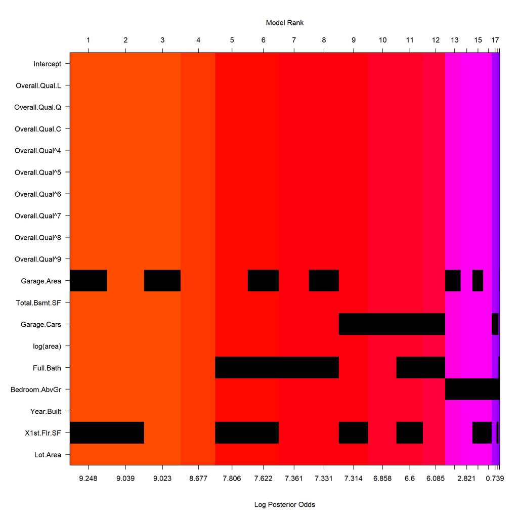

```r
# Model selection using BAM
model.bas <- bas.lm(log(price) ~ Overall.Qual + Garage.Area +
                   Total.Bsmt.SF + Garage.Cars + log(area) +
                   Full.Bath + Bedroom.AbvGr + Year.Built +
                   X1st.Flr.SF + Lot.Area, data = ames_train,
                   prior = "AIC", modelprior=uniform())
image(model.bas, rotate = FALSE)
```

```r
# Initial Model: log(price) ~ Overall.Qual + Garage.Area + Total.Bsmt.SF + Garage.Cars + log(area) + Full.Bath + Bedroom.AbvGr + Year.Built + X1st.Flr.SF + Lot.Area

# Model AIC: log(price) ~ Overall.Qual + Total.Bsmt.SF + Garage.Cars + log(area) + Full.Bath + Bedroom.AbvGr + Year.Built + Lot.Area

# Model BIC : log(price) ~ Overall.Qual + Total.Bsmt.SF + Garage.Cars + log(area) + Bedroom.AbvGr + Year.Built + Lot.Area
```

### 2.2.3 Section 2.3 Initial Model Residuals

One way to assess the performance of a model is to examine the model’s residuals. In the space below, create a residual plot for your preferred model from above and use it to assess whether your model appears to fit the data well. Comment on any interesting structure in the residual plot (trend, outliers, etc.) and briefly discuss potential implications it may have for your model and inference / prediction you might produce.

#### 2.2.3.1 Residuals plot

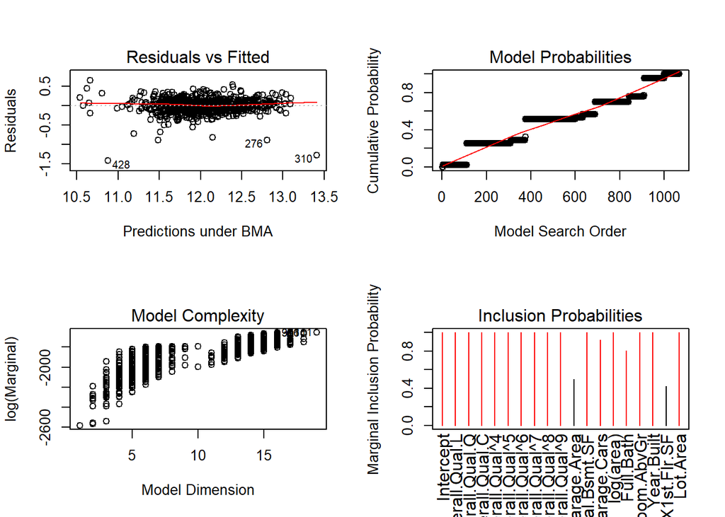

```r
par(mfrow = c(2,2))
plot(model.bas)
```

```r
pred_train <- predict(model.bas,ames_train,estimator = "BMA")
resid_train <- na.omit(ames_train$price - exp(pred_train$fit))
data.fit.resid <- data.frame(fitted = na.omit(exp(pred_train$fit)), resid = resid_train)
overprice <- ames_train %>% dplyr::select(Lot.Area, Land.Slope, Year.Built, Year.Remod.Add, Bedroom.AbvGr, price)
overprice$predicted <- exp(pred_train$fit)
overprice[c(428,181,310),]
```

```
## # A tibble: 3 x 7
##   Lot.Area Land.Slope Year.Built Year.Remod.Add Bedroom.AbvGr  price
##      <int> <fct>           <int>          <int>         <int>  <int>
## 1     9656 Gtl              1923           1970             2  12789
## 2    11900 Gtl              1977           1977             3  82500
## 3    40094 Gtl              2007           2008             3 184750
## # ... with 1 more variable: predicted <dbl>
```

#### 2.2.3.2 Q-Q plot

The QQ plot of residuals can be used to visually check the normality assumption. The normal probability plot of residuals should approximately follow a straight line.

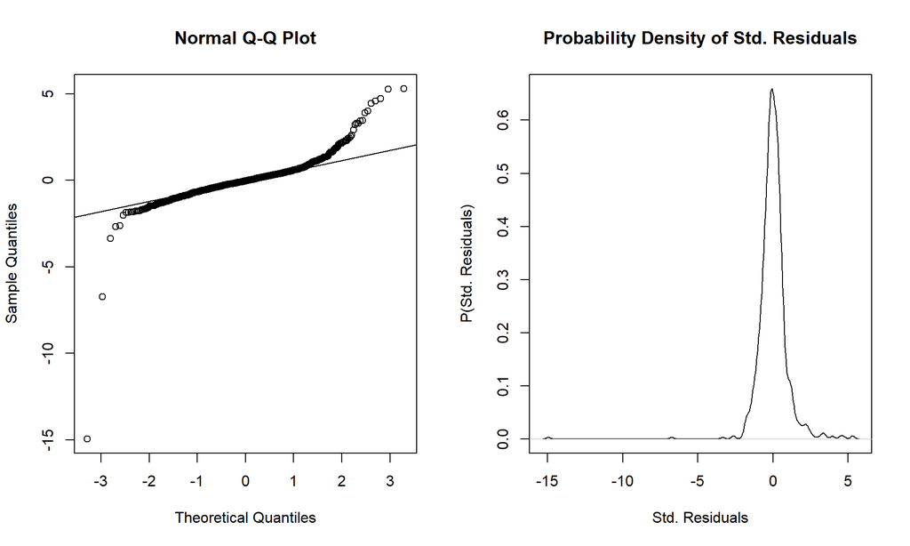

```r
# Quantile-Quantile Plot of Residuals

mu_resid <- mean(resid_train, na.rm=TRUE)
sd_resid <- sd(resid_train, na.rm=TRUE)
std_resid <- (resid_train-mu_resid)/sd_resid
par(mfrow=c(1,2))
qqnorm(std_resid, lty = 2)
qqline(std_resid)
plot(density(std_resid), main="Probability Density of Std. Residuals", xlab="Std. Residuals", ylab="P(Std. Residuals)")
```

#### 2.2.3.3 Scale plot

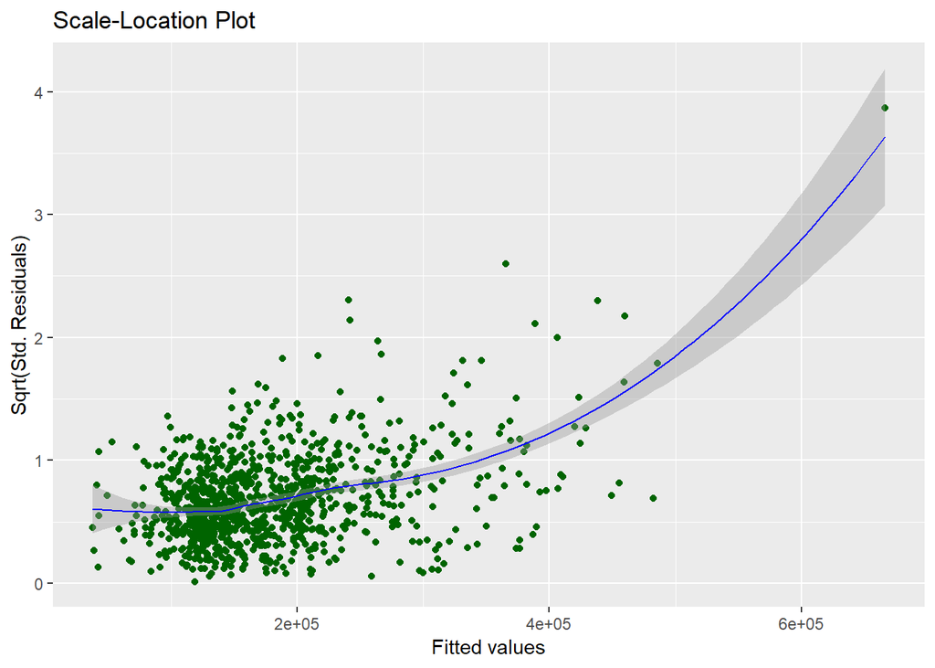

```r
sqrt_std_resid <- sqrt(abs(std_resid))
plot_dat <- data.frame(fitted = na.omit(exp(pred_train$fit)), resid = resid_train, sqrt_std_resid = sqrt_std_resid)
ggplot(plot_dat, aes(x = fitted, y = sqrt_std_resid)) +
  geom_point(colour = 'darkgreen') +
  geom_smooth(method = 'loess', color= "blue", lwd = 0.5) +
  labs(title = "Scale-Location Plot", y = "Sqrt(Std. Residuals)", x = "Fitted values")
```

The scale plot is used to check the homogeneity of variance of the residuals (homoscedasticity). Horizontal line with equally spread points is a good indication of homoscedasticity. At higher fitted values, the variance and bias in model predictions diverges as the predicted price increases. To overcome this issue, we can either remove all houses that the model overestimated or add correction to the model.

### 2.2.4 Section 2.4 Initial Model RMSE

You can calculate it directly based on the model output. Be specific about the units of your RMSE (depending on whether you transformed your response variable). The value you report will be more meaningful if it is in the original units (dollars).

```r
model.bas <- bas.lm(log(price) ~ Overall.Qual + Garage.Area +
                   Total.Bsmt.SF + Garage.Cars + log(area) +
                   Full.Bath + Bedroom.AbvGr + Year.Built +
                   X1st.Flr.SF + Lot.Area, data = ames_train,
                   prior = "AIC", modelprior=uniform())

pred_train <- predict(model.bas,ames_train,estimator = "BMA")
resid_train <- na.omit(ames_train$price - exp(pred_train$fit))
rmse_train <- sqrt(mean(resid_train^2))
paste('RMSE for BMA model under ames_train = ', format(rmse_train, digit = 7))
```

```
## [1] "RMSE for BMA model under ames_train =  32422.83"
```

### 2.2.5 Section 2.5 Overfitting

The process of building a model generally involves starting with an initial model (as you have done above), identifying its shortcomings, and adapting the model accordingly. This process may be repeated several times until the model fits the data reasonably well. However, the model may do well on training data but perform poorly out-of-sample (meaning, on a dataset other than the original training data) because the model is overly-tuned to specifically fit the training data. This is called âoverfitting.â To determine whether overfitting is occurring on a model, compare the performance of a model on both in-sample and out-of-sample data sets. To look at performance of your initial model on out-of-sample data, you will use the data set `ames_test`.

```r
load("ames_test.Rdata")
```

Use your model from above to generate predictions for the housing prices in the test data set. Are the predictions significantly more accurate (compared to the actual sales prices) for the training data than the test data? Why or why not? Briefly explain how you determined that (what steps or processes did you use)?

```r
pred_test <- predict(model.bas,ames_test,estimator = "BMA")
```

[output not shown]

```r
resid_test <- na.omit(ames_test$price - exp(pred_test$fit))
```

[output not shown]

```r
rmse_test <- sqrt(mean(resid_test^2))
```

[output not shown]

```r
paste('RMSE for BMA model under ames_test = ', format(rmse_test, digit = 7))
```

[output not shown]

**Note to the learner:** If in real-life practice this out-of-sample analysis shows evidence that the training data fits your model a lot better than the test data, it is probably a good idea to go back and revise the model (usually by simplifying the model) to reduce this overfitting. For simplicity, we do not ask you to do this on the assignment, however.

## 2.3 Part 3 Development of a Final Model

Now that you have developed an initial model to use as a baseline, create a final model with *at most* 20 variables to predict housing prices in Ames, IA, selecting from the full array of variables in the dataset and using any of the tools that we introduced in this specialization.

Carefully document the process that you used to come up with your final model, so that you can answer the questions below.

### 2.3.1 Section 3.1 Final Model

Provide the summary table for your model.

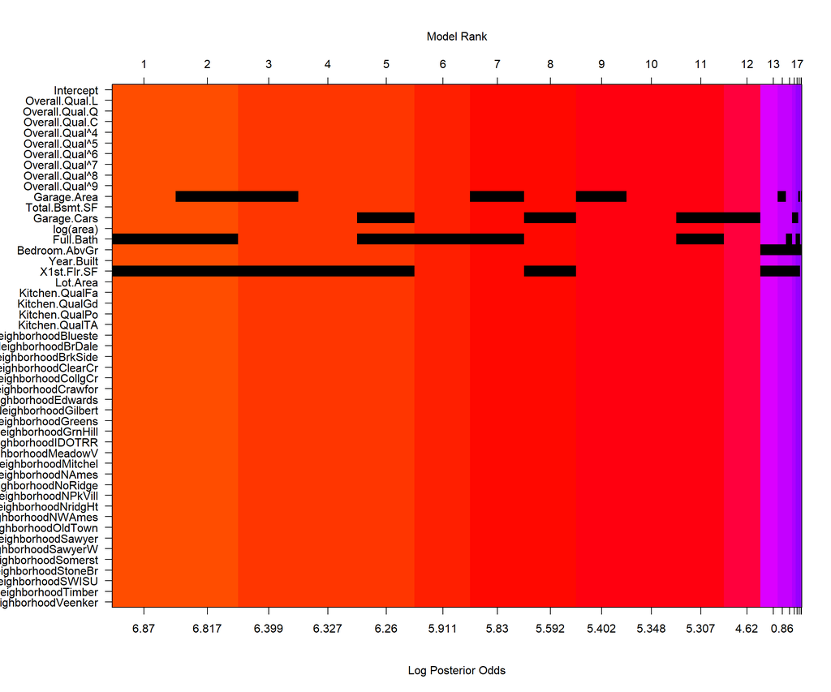

```r
ames_train = ames_train[-310,]
model.final <- bas.lm(log(price) ~ Overall.Qual + Garage.Area +
                   Total.Bsmt.SF + Garage.Cars + log(area) +
                   Full.Bath + Bedroom.AbvGr + Year.Built +
                   X1st.Flr.SF + Lot.Area + Kitchen.Qual+ Neighborhood, data = ames_train,
                   prior = "AIC", modelprior=uniform())
image(model.final, rotate = FALSE)
```

### 2.3.2 Section 3.2 Transformation

Did you decide to transform any variables? Why or why not? Explain in a few sentences.

In this model, we transform price and area because log-tranform both price and area provide the most linear relationship between price and area.

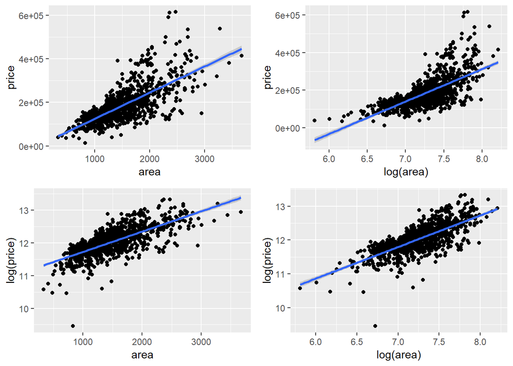

```r
# No log transform
p51 <- ggplot(ames_train, aes(x = area, y = price)) +
  geom_point() +
  stat_smooth(method = 'lm')

#Log area transform
p52 <- ggplot(ames_train, aes(x = log(area), y = price)) +
  geom_point() +
  stat_smooth(method = 'lm')

#Log price transform
p53 <- ggplot(ames_train, aes(x = area, y = log(price))) +
  geom_point() +
  stat_smooth(method = 'lm')

# Log transform both
p54 <- ggplot(ames_train, aes(x = log(area), y = log(price))) +
  geom_point() +
  stat_smooth(method = 'lm')

grid.arrange(p51, p52, p53, p54, ncol = 2)
```

We see that log-transform both price and area makes the relationship appear to be the most linear

### 2.3.3 Section 3.3 Variable Interaction

Did you decide to include any variable interactions? Why or why not? Explain in a few sentences.

Use the `vif` function in the R package car to test for multicollinearity. - VIF = 1 : not correlated - 1< VIF < 5: moderatedly correlated - 5< VIF < 10: highly correlated

```r
library(car)
Final.Model <- as.formula(price ~ Overall.Qual + Garage.Area +
                   Total.Bsmt.SF + Garage.Cars + area +
                   Full.Bath + Bedroom.AbvGr + Year.Built +
                   X1st.Flr.SF + Lot.Area + Kitchen.Qual)
vif(lm(Final.Model, ames_train))
```

```
##                   GVIF Df GVIF^(1/(2*Df))
## Overall.Qual  7.366945  9        1.117333
## Garage.Area   5.765524  1        2.401151
## Total.Bsmt.SF 3.804495  1        1.950511
## Garage.Cars   6.353370  1        2.520589
## area          4.080910  1        2.020126
## Full.Bath     2.386011  1        1.544672
## Bedroom.AbvGr 1.949106  1        1.396104
## Year.Built    2.320623  1        1.523359
## X1st.Flr.SF   4.021882  1        2.005463
## Lot.Area      1.144870  1        1.069986
## Kitchen.Qual  4.041765  4        1.190752
```

We see that all features in our model are moderatedly or highly correlated so we will not include variable interation

### 2.3.4 Section 3.4 Variable Selection

What method did you use to select the variables you included? Why did you select the method you used? Explain in a few sentences.

### 2.3.5 Section 3.5 Model Testing

How did testing the model on out-of-sample data affect whether or how you changed your model? Explain in a few sentences.

## 2.4 Part 4 Final Model Assessment

### 2.4.1 Section 4.1 Final Model Residual

For your final model, create and briefly interpret an informative plot of the residuals.

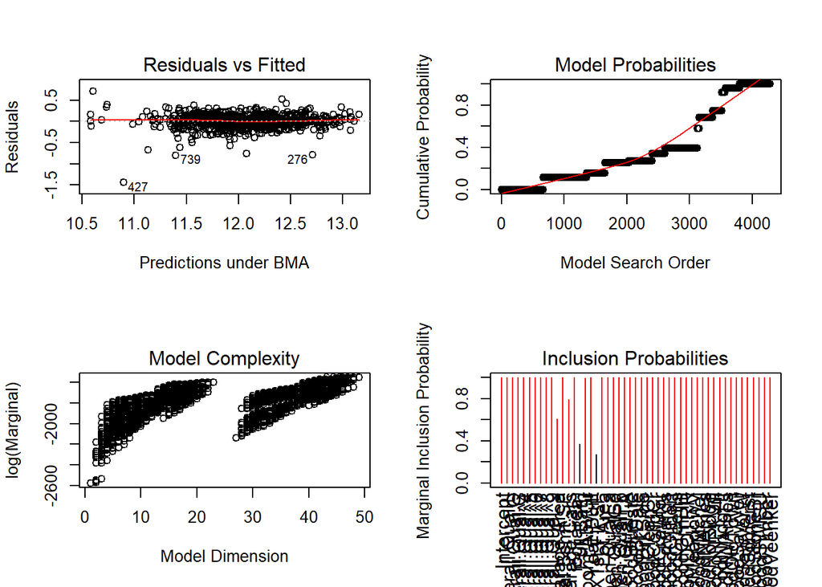

```r
par(mfrow = c(2,2))
plot(model.final)
```

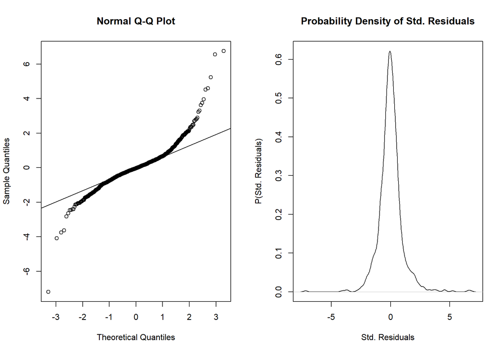

```r
pred_train2 <- predict(model.final,ames_train,estimator = "BMA")
resid_train2 <- na.omit(ames_train$price - exp(pred_train2$fit))
mu_resid2 <- mean(resid_train2, na.rm=TRUE)
sd_resid2 <- sd(resid_train2, na.rm=TRUE)
std_resid2 <- (resid_train2-mu_resid2)/sd_resid2
# Quantile-Quantile Plot of Residuals
par(mfrow=c(1,2))
qqnorm(std_resid2, lty = 2)
qqline(std_resid2)
plot(density(std_resid2), main="Probability Density of Std. Residuals",

    xlab="Std. Residuals", ylab="P(Std. Residuals)")
```

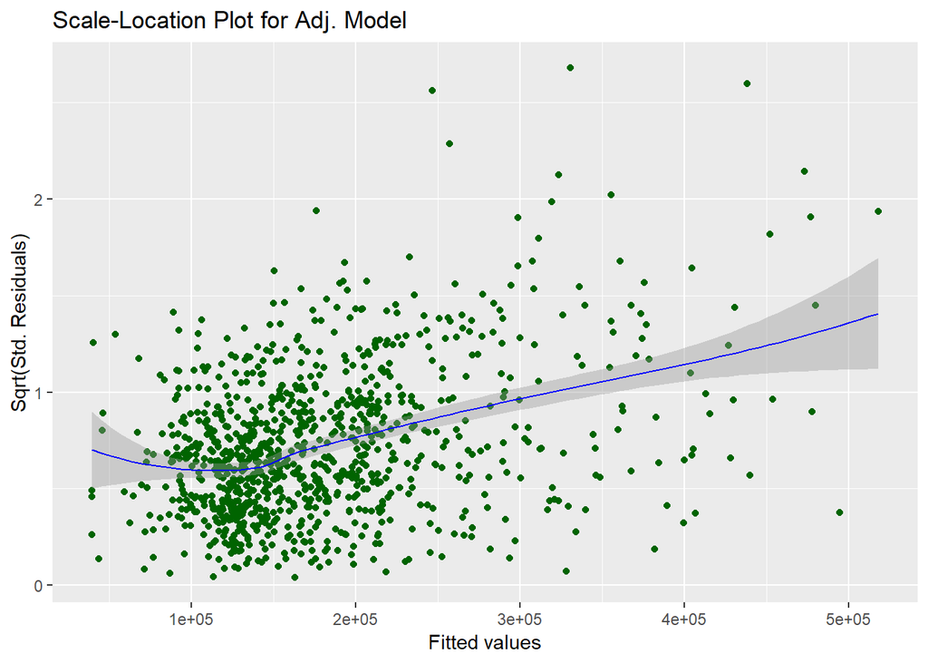

```r
#Scale plot
sqrt_std_resid2 <- sqrt(abs(std_resid2))
plot_dat2 <- data.frame(fitted2 = na.omit(exp(pred_train2$fit)), resid2 = resid_train2, sqrt_std_resid2 = sqrt_std_resid2)
ggplot(plot_dat2, aes(x = fitted2, y = sqrt_std_resid2)) +
  geom_point(color = 'darkgreen') +
  geom_smooth(method = 'loess', color= "blue", lwd = 0.5) +
  labs(title = "Scale-Location Plot for Adj. Model", y = "Sqrt(Std. Residuals)", x = "Fitted values")
```

The variability (variances) of the residual points increases with the value of the fitted outcome variable, suggesting non-constant variances in the residuals errors (or heteroscedasticity).

### 2.4.2 Section 4.2 Final Model RMSE

For your final model, calculate and briefly comment on the RMSE.

```r
sqrt(mean(resid_train2^2))
```

```
## [1] 25431.84
```

```r
ames_test = ames_test %>% filter(Neighborhood != "Landmrk")
pred_test2 <- predict(model.final, newdata = ames_test, estimator="HPM")
```

[output not shown]

```r
test2_rmse <- sqrt(mean((exp(pred_test2$fit) - ames_test$price)^2))
```

[output not shown]

```r
test2_rmse
```

[output not shown]

### 2.4.3 Section 4.3 Final Model Evaluation

What are some strengths and weaknesses of your model?

### 2.4.4 Section 4.4 Final Model Validation

Testing your final model on a separate, validation data set is a great way to determine how your model will perform in real-life practice.

You will use the âames_validationâ dataset to do some additional assessment of your final model. Discuss your findings, be sure to mention: * What is the RMSE of your final model when applied to the validation data?  
* How does this value compare to that of the training data and/or testing data? * What percentage of the 95% predictive confidence (or credible) intervals contain the true price of the house in the validation data set?  
* From this result, does your final model properly reflect uncertainty?

```r
load("ames_validation.Rdata")
```

```r
# RMSE
pred.v.HPM <- predict(model.final, ames_validation,
                    estimator="HPM",
                    prediction=TRUE, se.fit=TRUE)
```

[output not shown]

```r
v_rmse <- sqrt(mean((exp(pred.v.HPM$fit) - ames_validation$price)^2))
```

[output not shown]

```r
v_rmse
```

[output not shown]

```r
# Get dataset of predictions and confidence intervals
out = as.data.frame(cbind(exp(confint(pred.v.HPM)),
                          price = ames_validation$price))
```

[output not shown]

```r
# Fix names in dataset
colnames(out)[1:2] <- c("lwr", "upr")  #fix names
```

[output not shown]

```r
# Get Coverage
pred.v.HPM.coverage <- out %>% summarize(cover = sum(price >= lwr & price <= upr)/n())
```

[output not shown]

```r
pred.v.HPM.coverage
```

[output not shown]

## 2.5 Part 5 Conclusion

Provide a brief summary of your results, and a brief discussion of what you have learned about the data and your model.

In case that we have a lot of variables to choose as predictors, we should not only base on variables that show strong quantative information. Like in this model, `corrplot` showing more than 10 variables having strong relationship with price but there are some variables which actually affected the price of a house are excluded.

In short, to have a good model we must obtain a good data, explore the data to understand well about data, build model, diagnotic the model, test the model and validate the model * * *